# SQL joins

November 17 + 19, 2025

Jo Hardin

# Agenda 11/17/25

1. Joining

# `JOIN`ing

## All the `JOIN`s

- `JOIN` (aka `INNER JOIN`): include all of the rows that exist in both tables
- `LEFT JOIN`: include all of the rows in the first table.
- `RIGHT JOIN`: include all of the rows in the second table.
- `FULL OUTER JOIN`: include all rows in either table. (The functionality doesn’t exist in **MySQL** but can be created using joins and `UNION`.)
- `CROSS JOIN`: match each row of the first table with each row in the second table.

## All the `JOIN`s

Venn diagrams of the different types of joins.

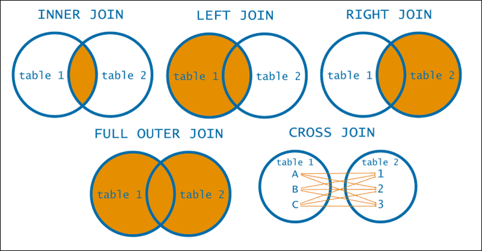

Venn diagrams describing different JOINs, image credit: phoenixNAP https://phoenixnap.com/kb/mysql-join

## All the `JOIN`s

Mini data tables of the different types of `JOIN`. (In **SQL** the missing values will be labeled as `NULL` (not `NA`).)

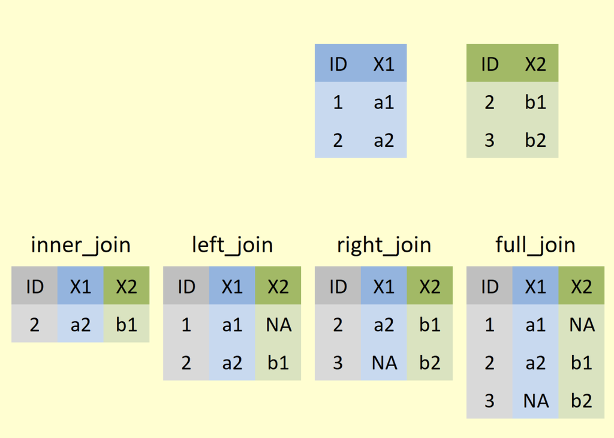

Mini data tables describing different JOINs, image credit: Statistics Globe blog, https://statisticsglobe.com/r-dplyr-join-inner-left-right-full-semi-anti

## All the `JOIN`s

Each `JOIN` clause needs four specific pieces of information:

1. The name of the first table you want to `JOIN`.
2. The type of `JOIN` being used.
3. The name of the second table you want to `JOIN`.
4. The condition(s) under which you want the records in the first table to match records in the second table.

## A toy example

Rock bands from the 60s.

```r
band_members
```

```
# A tibble: 3 × 2
  name  band
  <chr> <chr>
1 Mick  Stones
2 John  Beatles
3 Paul  Beatles
```

```r
band_instruments
```

```
# A tibble: 3 × 2
  name  plays
  <chr> <chr>
1 John  guitar
2 Paul  bass
3 Keith guitar
```

The function `sqldf()` in the **sqldf** **R** package allows for **SQL** commands on **R** objects.

## Rock bands - `INNER JOIN`

An inner join combines two datasets returning only the observations that exist in both of the original datasets.

```r
sqldf::sqldf(
  "SELECT star.name,
                     star.band,
                     inst.plays
              FROM band_members AS star
              JOIN band_instruments AS inst ON star.name = inst.name"
)
```

```
  name    band  plays
1 John Beatles guitar
2 Paul Beatles   bass
```

## Rock bands - `FULL JOIN`

A full join combines two datasets returning every observation that exists in either one of the original datasets.

```r
band_members |>
  full_join(band_instruments)
```

```
# A tibble: 4 × 3
  name  band    plays
  <chr> <chr>   <chr>
1 Mick  Stones  <NA>
2 John  Beatles guitar
3 Paul  Beatles bass
4 Keith <NA>    guitar
```

The `full_join()` function does not have an equivalent in **MySQL**. See later slides for using `JOIN`s and `UNION`s to produce a full join.

## Rock bands - `LEFT JOIN`

A left join combines two datasets returning every observation that exists in the left (or first) original dataset.

```r
sqldf::sqldf(
  "SELECT star.name,
                     star.band,
                      inst.plays
              FROM band_members AS star
              LEFT JOIN band_instruments AS inst
              ON star.name = inst.name"
)
```

```
  name    band  plays
1 Mick  Stones   <NA>
2 John Beatles guitar
3 Paul Beatles   bass
```

## Rock bands - `RIGHT JOIN`

A right join combines two datasets returning every observation that exists in the right (or second) original dataset.

```r
sqldf::sqldf(
  "SELECT inst.name,
                     star.band,
                      inst.plays
              FROM band_members AS star
              RIGHT JOIN band_instruments AS inst
              ON star.name = inst.name"
)
```

```
   name    band  plays
1  John Beatles guitar
2  Paul Beatles   bass
3 Keith    <NA> guitar
```

## Rock bands - `CROSS JOIN`

A cross join combines every row from one table with every row from another table to produce the Cartesian product of the two tables.

```r
sqldf::sqldf(
  "SELECT *
              FROM band_members AS star
              CROSS JOIN band_instruments AS inst"
)
```

```
  name    band  name  plays
1 Mick  Stones  John guitar
2 Mick  Stones  Paul   bass
3 Mick  Stones Keith guitar
4 John Beatles  John guitar
5 John Beatles  Paul   bass
6 John Beatles Keith guitar
7 Paul Beatles  John guitar
8 Paul Beatles  Paul   bass
9 Paul Beatles Keith guitar
```

# Today’s example

## IMDb

Consider a database of information from [IMDb](https://www.imdb.com/).

[figure not shown]

## IMDb

21 tables in the `imdb` database! Lots of details on movies, TV series, video games, and more. Today interest is in movies (and details within, like actors and ratings).

```sql
SHOW TABLES;
```

Displaying records 1 - 10

| Tables_in_imdb |
| --- |
| aka_name |
| aka_title |
| cast_info |
| char_name |
| comp_cast_type |
| company_name |
| company_type |
| complete_cast |
| info_type |
| keyword |

## IMDb - glance through tables

```sql
SELECT * FROM kind_type
LIMIT 0, 10;
```

7 records

| id | kind |
| --- | --- |
| 1 | movie |
| 2 | tv series |
| 3 | tv movie |
| 4 | video movie |
| 5 | tv mini series |
| 6 | video game |
| 7 | episode |

## `JOIN` IMDb title + votes

In the `imdb` database, the `title` table includes information about the 4,626,322 titles in the database, including the `id`, `title`, `kind_id` (indicator for the kind of ID it is), and `production_year`. It does not, however, include the review of the title.

```sql
SELECT * FROM title LIMIT 0, 10;
```

Displaying records 1 - 10

| id | title | imdb_index | kind_id | production_year | imdb_id | phonetic_code | episode_of_id | season_nr | episode_nr | series_years | md5sum |
| --- | --- | --- | --- | --- | --- | --- | --- | --- | --- | --- | --- |
| 78460 | Adults Recat to the Simpsons (30th Anniversary) |  | 7 | 2017 |  | A3432 | 78406 |  |  |  | 2ae09eed7d576cc2c24774fed5b18168 |
| 70273 | (2016-05-18) |  | 7 | 2016 |  |  | 68058 |  |  |  | 511dfc14cfff7589d29a95abb30cd66a |
| 60105 | (2014-04-11) |  | 7 | 2014 |  |  | 59138 |  |  |  | c6cdce7e667e07713e431805c407feed |
| 32120 | (2008-05-01) |  | 7 | 2008 |  |  | 32060 |  |  |  | 100df65742caf5afd092b2e0ead67d8e |
| 97554 | SchmÃ¶lders Traum |  | 7 | 2001 |  | S2543 | 97302 | 10 | 1 |  | 46862a2f96f9fb2d59e8c9a11ecfdd28 |
| 57966 | (#1.1) |  | 7 | 2013 |  |  | 57965 | 1 | 1 |  | 409c37703766c4b24f8a86162fd9cf85 |
| 76391 | Anniversary |  | 7 | 1971 |  | A5162 | 76385 | 4 | 9 |  | 5e12ce73fac1d1dcf94136b6e9acd8f8 |
| 11952 | Angus Black/Lester Barrie/DC Curry |  | 7 | 2009 |  | A5214 | 11937 | 4 | 7 |  | 9c38b9e5601dc154444b73b518034aa1 |
| 1554 | New Orleans |  | 7 | 2003 |  | N6452 | 1508 | 2 | 11 |  | 621bea735740a547e862e4a3226f35d2 |
| 58442 | Kiss Me Kate |  | 7 | 2011 |  | K2523 | 58436 | 1 | 10 |  | 293e8c75c7f35a4035abf617962be5a9 |

## `JOIN` IMDb title + votes

The `movie_info_idx` table does not contain much information about each particular film. It does, however, have an indicator for the movie ID (given by `movie_id`) as well as the number of votes (given by `info` where `type_id = 100`).

```sql
SELECT * FROM movie_info_idx LIMIT 0, 6;
```

6 records

| id | movie_id | info_type_id | info | note |
| --- | --- | --- | --- | --- |
| 1 | 1 | 99 | 31.2.1..2. |  |
| 2 | 1 | 100 | 9 |  |
| 3 | 1 | 101 | 4.1 |  |
| 4 | 2 | 99 | 1000000102 |  |
| 5 | 2 | 100 | 61 |  |
| 6 | 2 | 101 | 6.4 |  |

## `JOIN` IMDb title + votes

- combine the titles with the number of votes so that each title with user votes is included (`INNER JOIN`)

```sql
SELECT title.id,
       title.title,
       movie_info_idx.info
FROM title
JOIN movie_info_idx ON title.id = movie_info_idx.movie_id
WHERE title.production_year = 2015
    AND title.kind_id = 1                  # movies only
    AND movie_info_idx.info_type_id = 100  # info_type is votes
    AND movie_info_idx.info > 150000       # at least 150,000 votes
ORDER BY movie_info_idx.info DESC
LIMIT 0, 20;
```

Displaying records 1 - 10

| id | title | info |
| --- | --- | --- |
| 4260166 | Star Wars: Episode VII - The Force Awakens | 691691 |
| 3915213 | Mad Max: Fury Road | 666484 |
| 4389619 | The Martian | 583987 |
| 3313672 | Avengers: Age of Ultron | 540606 |
| 4414139 | The Revenant | 526189 |
| 3787790 | Jurassic World | 471237 |
| 3752999 | Inside Out | 443051 |
| 3292159 | Ant-Man | 390965 |
| 4364483 | The Hateful Eight | 363199 |
| 4251736 | Spectre | 319875 |

Some aspects of the query are worth pointing out:

- The variables in the output are given in the `SELECT` clause. The `id` and `title` (both from the `title` table) and the `info` from the `movie_info_idx` which represents the number of IMDb votes.
- The variables are preceded by the table from which they came. While not always necessary, it is good practice so as to avoid confusion.
- The `JOIN` happens by linking the `id` variable in the `title` table with the `movie_id` variable in the `movie_info_idx` table.
- The `LIMIT` wasn’t necessary (there are only 12 observations), but it’s good practice so that we don’t end up with unwieldy query results.
- The `WHERE` clause happens before the `JOIN` action, despite being written after.
- In the `WHERE` clause, we keep only movies, only 2015 production year, and only at least 150,000 votes.

## `JOIN` IMDb title + actress

`cast_info` contains the `person_id` and the `movie_id`

```sql
SELECT * FROM cast_info LIMIT 0, 10;
```

Displaying records 1 - 10

| id | person_id | movie_id | person_role_id | note | nr_order | role_id |
| --- | --- | --- | --- | --- | --- | --- |
| 1 | 1 | 3432997 | 1 |  | 31 | 1 |
| 2 | 2 | 1901690 | 2 |  |  | 1 |
| 3 | 3 | 4027567 | 2 |  | 25 | 1 |
| 4 | 3 | 4282876 | 3 |  | 22 | 1 |
| 5 | 4 | 3542672 |  |  | 12 | 1 |
| 6 | 5 | 3331520 | 4 | (as $hutter Boy) | 10 | 1 |
| 7 | 5 | 4027191 | 2 | (as $hutter Boy) | 1 | 1 |
| 8 | 5 | 4195731 | 5 | (uncredited) |  | 1 |
| 9 | 5 | 4263956 | 6 | (uncredited) |  | 1 |
| 10 | 5 | 4267787 | 7 | (uncredited) |  | 1 |

## `JOIN` IMDb title + actress

`aka_name` contains `person_id` and `name` (of actor)

```sql
SELECT * FROM aka_name LIMIT 0, 10;
```

Displaying records 1 - 10

[output not shown]

## `JOIN` IMDb title + actress

`title` contains `id` and `title` (of the movie)

```sql
SELECT * FROM title LIMIT 0, 10;
```

Displaying records 1 - 10

| id | title | imdb_index | kind_id | production_year | imdb_id | phonetic_code | episode_of_id | season_nr | episode_nr | series_years | md5sum |
| --- | --- | --- | --- | --- | --- | --- | --- | --- | --- | --- | --- |
| 78460 | Adults Recat to the Simpsons (30th Anniversary) |  | 7 | 2017 |  | A3432 | 78406 |  |  |  | 2ae09eed7d576cc2c24774fed5b18168 |
| 70273 | (2016-05-18) |  | 7 | 2016 |  |  | 68058 |  |  |  | 511dfc14cfff7589d29a95abb30cd66a |
| 60105 | (2014-04-11) |  | 7 | 2014 |  |  | 59138 |  |  |  | c6cdce7e667e07713e431805c407feed |
| 32120 | (2008-05-01) |  | 7 | 2008 |  |  | 32060 |  |  |  | 100df65742caf5afd092b2e0ead67d8e |
| 97554 | SchmÃ¶lders Traum |  | 7 | 2001 |  | S2543 | 97302 | 10 | 1 |  | 46862a2f96f9fb2d59e8c9a11ecfdd28 |
| 57966 | (#1.1) |  | 7 | 2013 |  |  | 57965 | 1 | 1 |  | 409c37703766c4b24f8a86162fd9cf85 |
| 76391 | Anniversary |  | 7 | 1971 |  | A5162 | 76385 | 4 | 9 |  | 5e12ce73fac1d1dcf94136b6e9acd8f8 |
| 11952 | Angus Black/Lester Barrie/DC Curry |  | 7 | 2009 |  | A5214 | 11937 | 4 | 7 |  | 9c38b9e5601dc154444b73b518034aa1 |
| 1554 | New Orleans |  | 7 | 2003 |  | N6452 | 1508 | 2 | 11 |  | 621bea735740a547e862e4a3226f35d2 |
| 58442 | Kiss Me Kate |  | 7 | 2011 |  | K2523 | 58436 | 1 | 10 |  | 293e8c75c7f35a4035abf617962be5a9 |

## `JOIN` IMDb title + actress

Goal: identify the actresses in those movies with the highest number of votes.

```sql
SELECT DISTINCT t.title,
       idx.info,
       a.person_id,
       n.name
FROM title AS t
JOIN movie_info_idx AS idx ON t.id = idx.movie_id
JOIN cast_info AS a ON idx.movie_id = a.movie_id
JOIN aka_name AS n ON a.person_id = n.person_id
WHERE t.production_year = 2015
    AND t.kind_id = 1           # movies only
    AND idx.info_type_id = 100  # info_type is votes
    AND idx.info > 150000       # at least 150,000 votes
    AND a.role_id = 2           # actresses only
ORDER BY a.person_id
LIMIT 0, 50;
```

Displaying records 1 - 10

| title | info | person_id | name |
| --- | --- | --- | --- |
| Mission: Impossible - Rogue Nation | 266759 | 2674172 | Sofz |
| Mission: Impossible - Rogue Nation | 266759 | 2674172 | Sof |
| Focus | 172680 | 2678594 | Labouisse, Kate |
| Mad Max: Fury Road | 666484 | 2681098 | Michelle, Debra |
| The Hunger Games: Mockingjay - Part 2 | 214569 | 2685496 | Harris, Ahnie |
| The Hunger Games: Mockingjay - Part 2 | 214569 | 2685496 | Harris, Jasmine |
| Creed | 183904 | 2686218 | Kareema, Kiana A. |
| Ant-Man | 390965 | 2687271 | Akana, Anna Kay |
| Inside Out | 443051 | 2689505 | Allen, Lori |
| Inside Out | 443051 | 2689505 | Denniberg, Lori Alan |

Connecting the most popular movies of 2015 with the actresses in those movies requires a series of `JOIN`s. Note that to make the code less onerous, the `title` table has been aliased by `t`, the `movie_info_idx` table has been aliased by `idx`, the `cast_info` table has been aliased by `a`, and the `aka_name` table has been aliased by `n`.

There is a lot of data cleaning to do as some of the `person_id` values are one to many!! That is, the `person_id` matches multiple names in the `aka_name` database.

## Other `JOIN`s

Let’s look at `RIGHT JOIN` and `LEFT JOIN` using two new smaller tables.

1. The first has seven movies in it (from 2015 with at least 400,000 IMDb votes).
2. The second consists of almost 3 million actresses (`person_role_id = 2`). In order to find a subset of actresses, the `person_id > 3900000` was set arbitrarily (in order to have a smaller group with which to work).

Using subqueries, we can `JOIN` the two datasets using different `JOIN` techniques.

## movies:

```sql
SELECT t.id,
       t.title,
       idx.info,
       (SELECT COUNT(*)
       FROM title AS t
       JOIN movie_info_idx AS idx ON idx.movie_id = t.id
       WHERE t.production_year = 2015
             AND t.kind_id = 1
             AND idx.info_type_id = 100
             AND idx.info > 400000) AS row_count
FROM title AS t
JOIN movie_info_idx AS idx ON idx.movie_id = t.id
WHERE t.production_year = 2015
    AND t.kind_id = 1             # movies only
    AND idx.info_type_id = 100    # info_type is votes
    AND idx.info > 400000         # at least 400,000 votes
ORDER BY idx.info DESC;
```

7 records

| id | title | info | row_count |
| --- | --- | --- | --- |
| 4260166 | Star Wars: Episode VII - The Force Awakens | 691691 | 7 |
| 3915213 | Mad Max: Fury Road | 666484 | 7 |
| 4389619 | The Martian | 583987 | 7 |
| 3313672 | Avengers: Age of Ultron | 540606 | 7 |
| 4414139 | The Revenant | 526189 | 7 |
| 3787790 | Jurassic World | 471237 | 7 |
| 3752999 | Inside Out | 443051 | 7 |

## actresses:

```sql
SELECT a.person_id,
       a.movie_id,
       n.name,
       (SELECT COUNT(*)
       FROM cast_info AS a
       JOIN aka_name AS n ON a.person_id = n.person_id
       WHERE a.person_role_id = 2
             AND a.person_id > 390000) AS row_count
FROM cast_info AS a
JOIN aka_name AS n ON a.person_id = n.person_id
       WHERE a.person_role_id = 2
             AND a.person_id > 3900000
LIMIT 0, 20;
```

Displaying records 1 - 10

| person_id | movie_id | name | row_count |
| --- | --- | --- | --- |
| 3900141 | 759802 | Simons, Rita Joanne | 2904759 |
| 3902258 | 4365829 | Singer, Rabbi Tovia | 2904759 |
| 3902699 | 3109788 | Singh, Sabine Erika | 2904759 |
| 3903035 | 3215866 | Val | 2904759 |
| 3904831 | 2468067 | Masha | 2904759 |
| 3904928 | 3654347 | Fei, Siu Yin | 2904759 |
| 3904928 | 3654347 | Hsiao, Yen-fei | 2904759 |
| 3904928 | 3654347 | Siu, Yinfei | 2904759 |
| 3904928 | 3654347 | Xiao, Yanfei | 2904759 |
| 3904928 | 3654347 | Yin-Fai, Siu | 2904759 |

## Inner `JOIN`

With an inner `JOIN`, there are 32 rows corresponding to all the actresses in the seven 2015 films with the most votes. Because the `JOIN` is an intersection of the two tables, only the actresses with `person_id` above 3900000 are included.

```sql
SELECT * FROM
(SELECT t.id,
       t.title
FROM title AS t
JOIN movie_info_idx AS idx ON idx.movie_id = t.id
WHERE t.production_year = 2015
    AND t.kind_id = 1               # movies only
    AND idx.info_type_id = 100      # info_type is votes
    AND idx.info > 400000) AS movs  # at least 400,000 votes
INNER JOIN (SELECT a.person_id,
       a.movie_id,
       n.name
    FROM cast_info AS a
    JOIN aka_name AS n ON a.person_id = n.person_id
    WHERE a.role_id = 2             # acresses only
        AND a.person_id > 3900000) AS acts ON acts.movie_id = movs.id
LIMIT 0, 300;
```

Displaying records 1 - 10

| id | title | person_id | movie_id | name |
| --- | --- | --- | --- | --- |
| 3313672 | Avengers: Age of Ultron | 3916648 | 3313672 | Smulders, Jacoba Francisca Maria |
| 3752999 | Inside Out | 4122876 | 3752999 | Kuzniar, Lennon Wynn |
| 3787790 | Jurassic World | 3938423 | 3787790 | Norvell, Ingrid |
| 3787790 | Jurassic World | 3938423 | 3787790 | Norvell, Ingrid |
| 3787790 | Jurassic World | 3950111 | 3787790 | Sallaway, Seannon Jane |
| 3787790 | Jurassic World | 4079047 | 3787790 | Washington, Kelly Lynn |
| 3787790 | Jurassic World | 4079047 | 3787790 | Washington, Kelly Lynn |
| 3787790 | Jurassic World | 4084626 | 3787790 | Weeks, Jency |
| 3787790 | Jurassic World | 4084626 | 3787790 | Jenc |
| 3787790 | Jurassic World | 4084626 | 3787790 | Little J |

## `RIGHT JOIN`

With a `RIGHT JOIN`, there are more than 300 rows (the `LIMIT` clause keeps us from knowing how many rows, but there are a LOT!) corresponding to all the actresses whose `person_id` above 3900000 are included. Those actresses who acted in one of the seven top 2015 films are also included in the full results table, but they don’t happen to be in the truncated output here.

```sql
SELECT * FROM
(SELECT t.id,
       t.title
FROM title AS t
JOIN movie_info_idx AS idx ON idx.movie_id = t.id
WHERE t.production_year = 2015
    AND t.kind_id = 1               # movies only
    AND idx.info_type_id = 100      # info_type is votes
    AND idx.info > 400000) AS movs  # at least 400,000 votes
RIGHT JOIN (SELECT a.person_id,
       a.movie_id,
       n.name
    FROM cast_info AS a
    JOIN aka_name AS n ON a.person_id = n.person_id
    WHERE a.role_id = 2             # acresses only
        AND a.person_id > 3900000) AS acts ON acts.movie_id = movs.id
LIMIT 0, 300;
```

Displaying records 1 - 10

| id | title | person_id | movie_id | name |
| --- | --- | --- | --- | --- |
|  |  | 3900001 | 3355298 | Simonis, Heidi |
|  |  | 3900001 | 3509490 | Simonis, Heidi |
|  |  | 3900001 | 3739780 | Simonis, Heidi |
|  |  | 3900001 | 3943329 | Simonis, Heidi |
|  |  | 3900001 | 165963 | Simonis, Heidi |
|  |  | 3900001 | 268249 | Simonis, Heidi |
|  |  | 3900001 | 268370 | Simonis, Heidi |
|  |  | 3900001 | 268406 | Simonis, Heidi |
|  |  | 3900001 | 268475 | Simonis, Heidi |
|  |  | 3900001 | 279082 | Simonis, Heidi |

## `LEFT JOIN`

With a `LEFT JOIN`, there are 33 rows corresponding to the actresses in the seven top 2015 movies. Only **The Revenant** did not have any actresses whose `person_id` is greater than 3900000.

```sql
SELECT * FROM
(SELECT t.id,
       t.title
FROM title AS t
JOIN movie_info_idx AS idx ON idx.movie_id = t.id
WHERE t.production_year = 2015
    AND t.kind_id = 1               # movies only
    AND idx.info_type_id = 100      # info_type is votes
    AND idx.info > 400000) AS movs  # at least 400,000 votes
LEFT JOIN (SELECT a.person_id,
       a.movie_id,
       n.name
    FROM cast_info AS a
    JOIN aka_name AS n ON a.person_id = n.person_id
    WHERE a.role_id = 2             # acresses only
        AND a.person_id > 3900000) AS acts ON acts.movie_id = movs.id
LIMIT 0, 300;
```

Displaying records 1 - 10

| id | title | person_id | movie_id | name |
| --- | --- | --- | --- | --- |
| 3313672 | Avengers: Age of Ultron | 3916648 | 3313672 | Smulders, Jacoba Francisca Maria |
| 3752999 | Inside Out | 4122876 | 3752999 | Kuzniar, Lennon Wynn |
| 3787790 | Jurassic World | 3938423 | 3787790 | Norvell, Ingrid |
| 3787790 | Jurassic World | 3938423 | 3787790 | Norvell, Ingrid |
| 3787790 | Jurassic World | 3950111 | 3787790 | Sallaway, Seannon Jane |
| 3787790 | Jurassic World | 4079047 | 3787790 | Washington, Kelly Lynn |
| 3787790 | Jurassic World | 4079047 | 3787790 | Washington, Kelly Lynn |
| 3787790 | Jurassic World | 4084626 | 3787790 | Weeks, Jency |
| 3787790 | Jurassic World | 4084626 | 3787790 | Jenc |
| 3787790 | Jurassic World | 4084626 | 3787790 | Little J |

## Counting repeat actresses

We might, for example, want to know how many names / spellings of a name with a specific `person_id` (above 3900000) exist for each `person_id` in each of the top voted seven films of 2015.

```sql
SELECT acts.person_id,
       COUNT(*) AS num_repeat_names
FROM (SELECT t.id,
       t.title
FROM title AS t
JOIN movie_info_idx AS idx ON idx.movie_id = t.id
WHERE t.production_year = 2015
    AND t.kind_id = 1               # movies only
    AND idx.info_type_id = 100      # info_type is votes
    AND idx.info > 400000) AS movs  # at least 400,000 votes
JOIN (SELECT a.person_id,
       a.movie_id,
       n.name
    FROM cast_info AS a
    JOIN aka_name AS n ON a.person_id = n.person_id
    WHERE a.role_id = 2             # acresses only
        AND a.person_id > 3900000) AS acts ON acts.movie_id = movs.id
GROUP BY acts.person_id;
```

Displaying records 1 - 10

| person_id | num_repeat_names |
| --- | --- |
| 3916648 | 1 |
| 4122876 | 1 |
| 3938423 | 2 |
| 3950111 | 1 |
| 4079047 | 2 |
| 4084626 | 3 |
| 4099458 | 1 |
| 3958614 | 1 |
| 3990819 | 2 |
| 4081131 | 2 |

## Counting number of actresses per film

We might, for example, want to know how many actresses with a specific `person_id` (above 3900000) are in each of the top voted seven films of 2015.

```sql
SELECT movs.id,
       movs.title,
       COUNT(*) AS num_actress
FROM (SELECT t.id,
       t.title
FROM title AS t
JOIN movie_info_idx AS idx ON idx.movie_id = t.id
WHERE t.production_year = 2015
    AND t.kind_id = 1               # movies only
    AND idx.info_type_id = 100      # info_type is votes
    AND idx.info > 400000) AS movs  # at least 400,000 votes
JOIN (SELECT a.person_id,
       a.movie_id,
       n.name
    FROM cast_info AS a
    JOIN aka_name AS n ON a.person_id = n.person_id
    WHERE a.role_id = 2             # acresses only
        AND a.person_id > 3900000) AS acts ON acts.movie_id = movs.id
GROUP BY movs.id;
```

6 records

| id | title | num_actress |
| --- | --- | --- |
| 3313672 | Avengers: Age of Ultron | 1 |
| 3752999 | Inside Out | 1 |
| 3787790 | Jurassic World | 9 |
| 3915213 | Mad Max: Fury Road | 5 |
| 4260166 | Star Wars: Episode VII - The Force Awakens | 15 |
| 4389619 | The Martian | 1 |

# Agenda 11/19/25

1. Unions

## `UNION`ing

In **SQL** a `UNION` clause combines two different tables by their rows (whereas `JOIN` combines two tables by columns). Think about `UNION` similarly to the `bind_rows()` command in **R**.

## `UNION`s

Silly example where the column names are ignored.

```sql
SELECT
    1 AS bar,
    2 AS foo

UNION

SELECT
    10 AS foo,
    20 AS bar;
```

2 records

| bar | foo |
| --- | --- |
| 1 | 2 |
| 10 | 20 |

## `UNION`

`UNION` is specifically designed to bind rows from two different `SELECT` queries where the variables have been selected in the same order.

However, to account for time, we require the movies from 2015 to have more votes (400,000) than the movies from 2017 (200,000).

That is, the `WHERE` clause is different for the two subqueries.

## `UNION`

```sql
(SELECT t.title,
        t.production_year,
        idx.info AS num_votes
    FROM title AS t
JOIN movie_info_idx AS idx ON idx.movie_id = t.id
WHERE t.production_year = 2015
    AND t.kind_id = 1
    AND idx.info_type_id = 100
    AND idx.info > 400000)

UNION

(SELECT t.title,
        t.production_year,
        idx.info AS num_votes
    FROM title AS t
JOIN movie_info_idx AS idx ON idx.movie_id = t.id
WHERE t.production_year = 2017
    AND t.kind_id = 1
    AND idx.info_type_id = 100
    AND idx.info > 200000)
LIMIT 0, 100;
```

Displaying records 1 - 10

| title | production_year | num_votes |
| --- | --- | --- |
| Avengers: Age of Ultron | 2015 | 540606 |
| Inside Out | 2015 | 443051 |
| Jurassic World | 2015 | 471237 |
| Mad Max: Fury Road | 2015 | 666484 |
| Star Wars: Episode VII - The Force Awakens | 2015 | 691691 |
| The Martian | 2015 | 583987 |
| The Revenant | 2015 | 526189 |
| Dunkirk | 2017 | 229089 |
| Guardians of the Galaxy Vol. 2 | 2017 | 281845 |
| Logan | 2017 | 397056 |

## `UNION ALL`

If the goal is to include duplicates across two tables, use `UNION ALL` instead of `UNION`.

Let’s say that the first table is all movies with production year after 2012 and number of votes greater than 500,000. The second table is movies with production year equal to 2015 and number of votes greater than 400,000.

The Martian would be in both tables.

## `UNION ALL`

With just `UNION`

```sql
(SELECT t.title,
        t.production_year,
        idx.info AS num_votes
    FROM title AS t
JOIN movie_info_idx AS idx ON idx.movie_id = t.id
WHERE t.production_year > 2012
    AND t.kind_id = 1
    AND idx.info_type_id = 100
    AND idx.info > 500000)

UNION

(SELECT t.title,
        t.production_year,
        idx.info AS num_votes
    FROM title AS t
JOIN movie_info_idx AS idx ON idx.movie_id = t.id
WHERE t.production_year = 2015
    AND t.kind_id = 1
    AND idx.info_type_id = 100
    AND idx.info > 400000)
ORDER BY production_year DESC, num_votes;
```

Displaying records 1 - 10

| title | production_year | num_votes |
| --- | --- | --- |
| Batman v Superman: Dawn of Justice | 2016 | 500037 |
| Deadpool | 2016 | 673887 |
| Inside Out | 2015 | 443051 |
| Jurassic World | 2015 | 471237 |
| The Revenant | 2015 | 526189 |
| Avengers: Age of Ultron | 2015 | 540606 |
| The Martian | 2015 | 583987 |
| Mad Max: Fury Road | 2015 | 666484 |
| Star Wars: Episode VII - The Force Awakens | 2015 | 691691 |
| Interstellar | 2014 | 1102826 |

## `UNION ALL`

When `UNION ALL` is applied, The Martian is listed twice in the results table.

```sql
(SELECT t.title,
        t.production_year,
        idx.info AS num_votes
    FROM title AS t
JOIN movie_info_idx AS idx ON idx.movie_id = t.id
WHERE t.production_year > 2012
    AND t.kind_id = 1
    AND idx.info_type_id = 100
    AND idx.info > 500000)

UNION ALL

(SELECT t.title,
        t.production_year,
        idx.info AS num_votes
    FROM title AS t
JOIN movie_info_idx AS idx ON idx.movie_id = t.id
WHERE t.production_year = 2015
    AND t.kind_id = 1
    AND idx.info_type_id = 100
    AND idx.info > 400000)
ORDER BY production_year DESC, num_votes;
```

Displaying records 1 - 10

| title | production_year | num_votes |
| --- | --- | --- |
| Batman v Superman: Dawn of Justice | 2016 | 500037 |
| Deadpool | 2016 | 673887 |
| Inside Out | 2015 | 443051 |
| Jurassic World | 2015 | 471237 |
| The Revenant | 2015 | 526189 |
| The Revenant | 2015 | 526189 |
| Avengers: Age of Ultron | 2015 | 540606 |
| Avengers: Age of Ultron | 2015 | 540606 |
| The Martian | 2015 | 583987 |
| The Martian | 2015 | 583987 |

## `FULL JOIN` with `UNION`

```r
sqldf::sqldf(
  "SELECT star.name,
                     star.band,
                     inst.plays
              FROM band_members AS star
              LEFT JOIN band_instruments AS inst
              ON star.name = inst.name

             UNION

             SELECT inst.name,
                    star.band,
                    inst.plays
             FROM band_instruments AS inst
             LEFT JOIN band_members AS star
             ON inst.name = star.name"
)
```

```
   name    band  plays
1  John Beatles guitar
2 Keith    <NA> guitar
3  Mick  Stones   <NA>
4  Paul Beatles   bass
```

## Best practice

It is always a good idea to terminate the **SQL** connection when you are done with it.

```r
DBI::dbDisconnect(con_imdb, shutdown = TRUE)
```